### 행렬과 배열

**같은 유형의 두 벡터를 결합해서 행렬 생성**

- x, y를 이용하여 열의 개수가 2인 행렬 M 생성
- x : 2, 2, 4
- y : 1.2, 3, 4.8

```r
x <- c(2, 2, 4)
y <- c(1.2, 3, 4.8)
M <- matrix(c(x, y), ncol=2, byrow=F) ;M
```

```
##      [,1] [,2]
## [1,]    2  1.2
## [2,]    2  3.0
## [3,]    4  4.8
```

```r
  #또는 열결합 함수 cbind(x,y)를 이용할 수도 있다
  #byrow : true->가로방향으로 순차적으로 행렬의 요소를 할당
```

**다른 유형의 벡터를 결합하여 리스트생성**

- x, y, a를 결합한 리스트 L 생성
- 각 벡터(변수)의 이름 x: kor, y: math, a: grade
- a : “low”, “high”, “high”

```r
a <- c("low", "high", "high")
L <- list(kor=x, math=y, grade=a) ;L
```

```
## $kor
## [1] 2 2 4
##
## $math
## [1] 1.2 3.0 4.8
##
## $grade
## [1] "low"  "high" "high"
```

**자동으로 벡터 생성**

1. 1에서 시작하여 20까지 1의 간격으로 값을 만드는 함수
2. 1을 10회 반복하여 벡터를 만드는 함수

```r
#1
seq(1, 20, 1)
```

```
##  [1]  1  2  3  4  5  6  7  8  9 10 11 12 13 14 15 16 17 18 19 20
```

```r
#2
rep(1, 10)
```

```
##  [1] 1 1 1 1 1 1 1 1 1 1
```

**3차원 배열 생성**

- M1 <- cbind(c(2, 2, 3), c(1.2, 3.0, 4.8))
- M2 <- cbind(c(1, 2, 3), c(4.2, 2.1, 1.9))
- M1과 M2를 결합하여 만든 3x2x2 배열 A

```r
M1 <- cbind(c(2, 2, 3), c(1.2, 3.0, 4.8))
M2 <- cbind(c(1, 2, 3), c(4.2, 2.1, 1.9))
A <- array(c(M1, M2), c(3, 2, 2)) ;A
```

```
## , , 1
##
##      [,1] [,2]
## [1,]    2  1.2
## [2,]    2  3.0
## [3,]    3  4.8
##
## , , 2
##
##      [,1] [,2]
## [1,]    1  4.2
## [2,]    2  2.1
## [3,]    3  1.9
```

### 행렬 관련 함수

**행렬 M (3x2) 에대해 다음의 함수 호출**

1. M1 <- M의 전치행렬 * M
2. M1의 역행렬
3. E <- M1의 대칭행렬
4. E를 사용하여 원래 M1 만들기

```r
M1 <- t(M) %*% M ;M1 #전치행렬: 행과 열을 치환
```

```
##      [,1]  [,2]
## [1,] 24.0 27.60
## [2,] 27.6 33.48
```

```r
solve(M1) #역행렬
```

```
##            [,1]       [,2]
## [1,]  0.8017241 -0.6609195
## [2,] -0.6609195  0.5747126
```

```r
E <- eigen(M1) ;E #대칭행렬
```

```
## eigen() decomposition
## $values
## [1] 56.744064  0.735936
##
## $vectors
##           [,1]       [,2]
## [1,] 0.6444916 -0.7646114
## [2,] 0.7646114  0.6444916
```

```r
E$vectors %*% diag(E$values) %*% t(E$vectors) #diag:대각행렬
```

```
##      [,1]  [,2]
## [1,] 24.0 27.60
## [2,] 27.6 33.48
```

### 논리 연산, 결측값,

**true-false를 1-0으로 바꾸는 함수**

```r
C <- c(T, T, F, F)
as.numeric(C)
```

```
## [1] 1 1 0 0
```

**결측값을 포함하는 자료 x에서 결측값을 제거하여 평균 구하기**

```r
mean(x, na.rm=T)
```

```
## [1] 2.666667
```

### factors

**수치형 변수를 범주형 변수로 바꾸기**

```r
species <- c(1,3,2,3)
species.f <- factor(species, levels = 1:3)
levels(species.f) <- c("species", "versicolor", "virginica")
```

**species.f의 수준별 빈도를 구하는 함수 호출**

```r
table(species.f)
```

```
## species.f
##    species versicolor  virginica
##          1          1          2
```

### 자료 변환과 데이터 부분세트

**x와 y를 더하여 tot라는 변수를 만들고 d2에 이 변수를 추가하여 d2a라는 리스트 만들기**

- x: 45, 32, 34, 28, 80
- y: 23, 37, 12, 76, 65
- 변수명 : kor, eng

```r
x <- c(45, 32, 34, 28, 80)
y <- c(23, 37, 12, 76, 65)
d2 <- list(kor = x, eng = y) ;d2
```

```
## $kor
## [1] 45 32 34 28 80
##
## $eng
## [1] 23 37 12 76 65
```

```r
d2a <- transform(d2, tot = kor + eng) ;d2a
```

```
##   kor eng tot
## 1  45  23  68
## 2  32  37  69
## 3  34  12  46
## 4  28  76 104
## 5  80  65 145
```

**d2a의 tot > 100인 레코드만 남긴 d3 생성**

```r
d3 <- subset(d2a, tot > 100) ;d3
```

```
##   kor eng tot
## 4  28  76 104
## 5  80  65 145
```

### 순서정렬과 순위

**order()의 용법**

```r
x <- c(12,6,4,7,8)
order(x)
```

```
## [1] 3 2 4 5 1
```

```r
#첫번째에 와야할 요소의 위치...
```

**순위를 구하는 함수에서 등순위를 처리하는 방법들**

- default - 평균 순위

```r
x <- c(12,12,4,7,8)
rank(x)
```

```
## [1] 4.5 4.5 1.0 2.0 3.0
```

- 먼저 나온 것에 우선 순위를 주는 방법

```r
rank(x, ties.method=c("first"))
```

```
## [1] 4 5 1 2 3
```

- 임의 순위를 주는 방법

```r
rank(x, ties.method = ("random"))
```

```
## [1] 4 5 1 2 3
```

### apply

**apply로 벡터 데이터 만들기**

- geyser 데이터에 대하여
- 각 행에 2개의 변수 값들을 더하여 sum이라는 변수를 생성하여
- 히스토그램 생성
- 자료요약 함수 호출

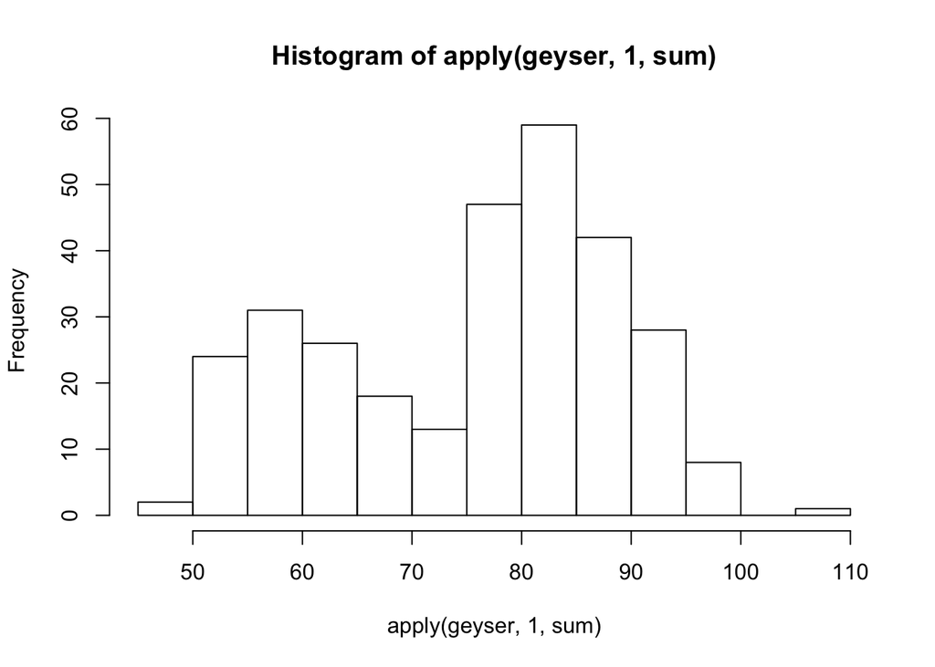

```r
geyser <- read.table("geyser299.txt", header=T)
hist(apply(geyser, 1, sum)) #1 : row
```

```r
summary(apply(geyser, 1, sum))
```

```
##    Min. 1st Qu.  Median    Mean 3rd Qu.    Max.
##   47.33   63.23   79.03   75.78   85.88  109.95
```

**apply로 리스트 데이터 만들기**

- 각 변수마다 median 계산

```r
lapply(geyser, median)
```

```
## $waiting
## [1] 76
##
## $duration
## [1] 4
```

### loop

**loop를 활용해서 피보나치 수열 만들기**

- a, b의 초기값은 1
- 100 미만의 값만 출력
- a, b는 20항 까지만 존재
- 피보나치 수열 : 첫째, 둘째 항이 1이고 그 뒤 모든 항은 바로 앞의 두개의 항의 합인 수열

```r
a <- rep(1,20)
b <- rep(1,20)
for (i in 3:20) {
    a[i] <- a[i-1] + a[i-2]
    b[i] <- b[i-1] + b[i-2]
}
a[a < 100]
```

```
##  [1]  1  1  2  3  5  8 13 21 34 55 89
```

```r
b[b < 100]
```

```
##  [1]  1  1  2  3  5  8 13 21 34 55 89
```

### 임의 수 생성

**균일 분포로부터 임의 수를 생성하는 함수**

- 최소, 최대의 경계가 각각 -1, 1
- 1000개를 생성

```r
x <- runif(1000, -1, 1)
```

**정규 분포로부터 임의 수를 생성하는 함수**

- 1000개를 생성
- 평균 0, 표준편차 1

```r
x <- rnorm(1000, 0, 1)
```

**이항 분포로부터 임의 수를 생성하는 함수**

- 1000개
- 크기 500
- 50%

```r
x <- rbinom(1000, 500, 0.5)
```

**포아송분포로부터 임의 수를 생성하는 함수**

- 1000개
- lambda=5 (평균)

```r
x <- rpois(1000, 5)
```

### R graphics: scatter plot

**geyser 자료에서 두 변수 waiting과 duration을 산점도 형태로 플롯**

- x 축의 범위를 40에서 110까지
- y 축의 범위를 1에서 6까지
- x 축의 레이블을 “waiting time (min)”
- y 축의 레이블을 “duration (min)”
- 그래프 전체 제목 “Geyser”
- 점 대신 케이스 번호

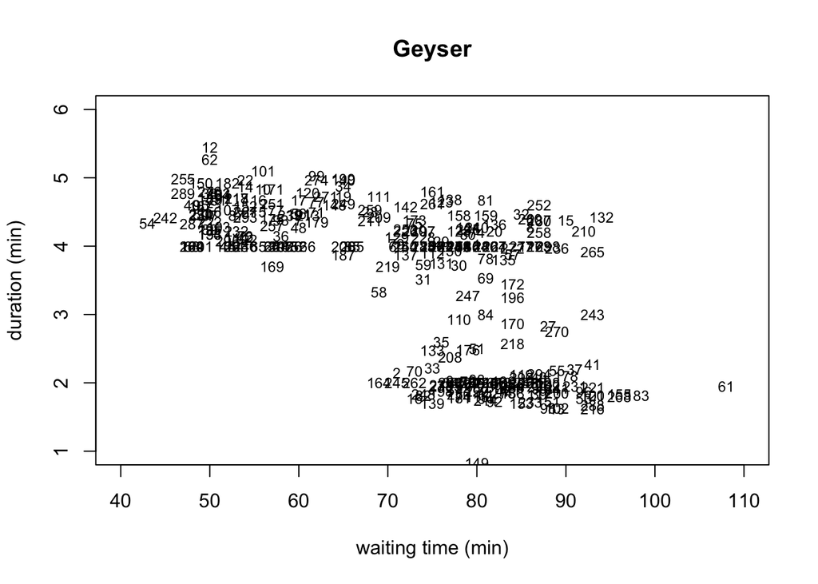

```r
geyser <- read.table("geyser299.txt", header=T)

attach(geyser)

plot(duration ~ waiting, xlim=c(40, 110), ylim=c(1, 6), xlab="waiting time (min)", ylab="duration (min)", main="Geyser", type = "n")

text(x = waiting, y = duration, cex = 0.75)
```

### R graphics: multiple frame

**여러 개의 그래프를 행렬 형태로 모아 찍기**

- 파라미터가 다른 4개의 베타분포 beta(a, b) 생성
- 2행 2열의 다중 프레임 선언
- 행의 순서로 다중 프레임 입력
- 각각의 히스토그램 그리기
- x축 0에서 1까지 0.1간격
- y축 상대도수
- y축의 범위 0부터 3까지

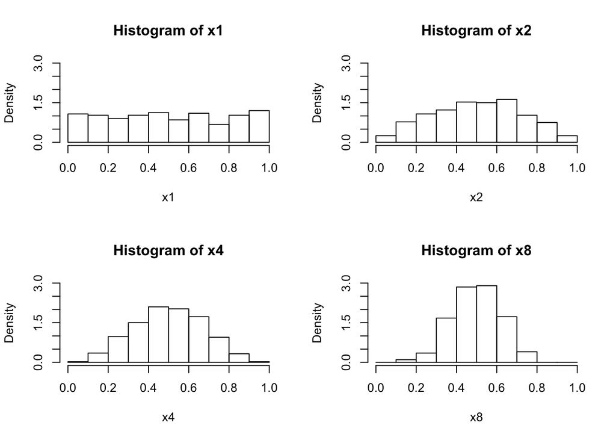

```r
x1 <- rbeta(400, 1, 1)
x2 <- rbeta(400, 2, 2)
x4 <- rbeta(400, 4, 4)
x8 <- rbeta(400, 8, 8)

par (mfrow = c(2,2))
  #2행 2열로 짜여진 다중 프레임
  #mfrow: 행의 순서로 다중 프레임 그래프가 제시됨
  #열의 순서로 제시하고자 한다면 mfcol

hist(x1, breaks = seq(0, 1, 0.1), freq = F, ylim = c(0, 3))
hist(x2, breaks = seq(0, 1, 0.1), freq = F, ylim = c(0, 3))
hist(x4, breaks = seq(0, 1, 0.1), freq = F, ylim = c(0, 3))
hist(x8, breaks = seq(0, 1, 0.1), freq = F, ylim = c(0, 3))
```

### 그래프를 겹쳐 그리기

**히스토그램과 곡선 그래프 겹쳐 그리기**

- 히스토그램
  - 자유도 df=5인 t분포로부터 1000개 랜덤 추출
  - y 축의 단위 : 상대도수
  - x 축의 범위 : (-5, 5)
  - y 축의 범위 : (0, 0.4)
  - 계급 구간의 수 : 20
  - x 축의 이름 : “sumulated observations”
  - 그래프 이름 : “t (df 5)”
- 곡선 그래프
  - 히스토그램의 t분포와 동일한 평균과 표준편차를 갖는 정규분포

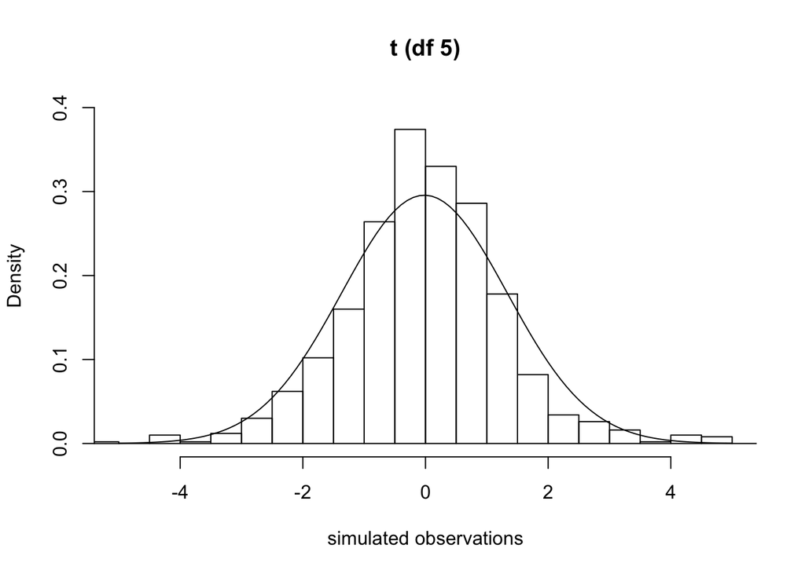

```r
x <- rt(1000, 5)
hist(x, freq=F, xlim=c(-5, 5), ylim=c(0, 0.4), nclass=20, xlab="simulated observations", main="t (df 5)")

m <- mean(x)
s <- sd(x)
curve(dnorm(x, m, s), add=T)
```

```r
  # dnorm : 값에 해당하는 정규분포의 높이를 알려준다
  # add=T : 겹쳐 그리기
```

### 사용자 정의 함수

**왜도와 첨도를 구하는 함수 만들기**

- skew =

[figure not shown]

- kurto =

[figure not shown]

```r
skew.and.kurto <- function(x){

  num1 <- mean((x-mean(x))^3)
  denom1 <- (mean((x-mean(x))^2))^1.5
  num2 <- mean((x-mean(x))^4)
  denom2 <- (mean((x-mean(x))^2))^2
  skew <- num1/denom1
  kurto <- num2/denom2 - 3

  return(c(skew, kurto))
}

z <- rnorm(1000)
sk <- skew.and.kurto(z)
sk
```

```
## [1] 0.049277331 0.009081862
```

### 데이터 세트 병합하기

**두 데이터 세트를 병합**

- data1과 data2를 병합
- data1은 mid.txt에서 불러온다
- data2는 finla.txt에서 불러온다
- data1과 data2의 모두에서 id가 있는 레코드만 data1.and.2에 병합

```r
data1 <- read.table("mid.txt", header=T) ;data1
```

```
##   id mid
## 1 23  43
## 2  4  56
## 3 78  29
## 4 54  99
```

```r
data2 <- read.table("final.txt", header=T) ;data2
```

```
##   id mid
## 1  4  77
## 2 23   2
## 3 54  19
## 4 70  31
```

```r
data1.and.2 <- merge(x=data1, y=data2, by.x="id", by.y="id") ;data1.and.2
```

```
##   id mid.x mid.y
## 1  4    56    77
## 2 23    43     2
## 3 54    99    19
```

- data1과 data2중 id가 있기만 하면 병합파일에 포함되도록 하는 방법

```r
data1.and.2 <- merge(x=data1, y=data2, by.x="id", by.y="id", all=T) ;data1.and.2
```

```
##   id mid.x mid.y
## 1  4    56    77
## 2 23    43     2
## 3 54    99    19
## 4 70    NA    31
## 5 78    29    NA
```

```r
  #all=T를 붙여준다
```

### 데이터 세트 분할

**함수 split() 사용하기**

- gr : 1, 2, 1, 1, 2
- 벡터를 범주형 변수화
- 범주 이름은 “low”, “high”
- score : 98, 82, 45, 23, 74
- score 데이터를 gr 범주를 기준으로 분리한 score.split 생성

```r
gr <- c(1, 2, 1, 1, 2)
gr <- factor(gr)
levels(gr) <- c("low", "high")
score <- c(98, 82, 45, 23, 74)
score.split <- split(score,gr) ;score.split
```

```
## $low
## [1] 98 45 23
##
## $high
## [1] 82 74
```

### 외부 데이터 파일 읽기

**SPSS 데이터나 SAS 데이터 파일을 읽는 방법**

- spss파일 “EEstock2000.sav”을 ee에 저장
- ee의 자료 메타정보 출력

```r
library(foreign)
ee <- read.spss("EEstock2000.sav")
str(ee)
```

```
## List of 4
##  $ date  : num [1:1349] 1.32e+10 1.32e+10 1.32e+10 1.32e+10 1.32e+10 ...
##  $ index : num [1:1349] 4665 4301 4218 4132 4255 ...
##  $ diff  : num [1:1349] 441.6 -364.5 -82.7 -86.2 123.5 ...
##  $ change: num [1:1349] 10.46 -7.81 -1.92 -2.04 2.99 ...
##  - attr(*, "label.table")=List of 4
##   ..$ date  : NULL
##   ..$ index : NULL
##   ..$ diff  : NULL
##   ..$ change: NULL
```

### 신뢰 구간 시뮬레이션

**실제 모평균이 신뢰 구간 안에 있는지 판단**

- 모평균 : 500
- 모표준편차 : 100 (모분산기지)
- 표본 : 100

```r
nreps <- 1000

ll <- numeric(nreps)
ul <- numeric(nreps)

n <- 100
mu <- 500
sigma <- 100

for (i in 1:nreps) {
  set.seed(i)
  x <- rnorm(n, mu, sigma)
  ll[i] <- mean(x) - qnorm(0.975)*sqrt(sigma^2/n)
  ul[i] <- mean(x) + qnorm(0.975)*sqrt(sigma^2/n)
}

which(ll >= 500)
```

```
##  [1] 173 218 286 290 300 356 360 435 484 501 522 559 682 687 709 881 890
## [18] 990
```

```r
which(ul <= 500)
```

```
##  [1]  85 159 265 269 318 339 353 367 373 450 473 483 531 624 669 671 673
## [18] 684 720 791 799 883 905 927
```

```r
mean( ll<=500 & ul>=500 )
```

```
## [1] 0.958
```

```r
table(ll >= 500)
```

```
##
## FALSE  TRUE
##   982    18
```

```r
table(ul <= 500)
```

```
##
## FALSE  TRUE
##   976    24
```